# ERGMs (Exponential Random Graph Model)

*“…how can we know how our observed network density compares to chance?”*

With ERGMs, we ask: given a sample of networks with like characteristics as the observed network (g(y)), what is the likelihood that these simulations produce the observed network? … we can compare the observed network statistics with statistics from simulated networks with like characteristics.

ERGMs attempt to bring a linear modeling approach to network estimation by assuming that these inherent interdependencies depend mostly on network characteristics that a savvy modeler can explicitly specify.

**Network density** is the ratio of the number of edges to the maximum possible number of edges

*Quotes from:* https://medium.com/@ben.roston/exponential-random-graph-models-ergms-network-analysis-and-you-2d7d756345e8

https://socialabstractions-blog.tumblr.com/post/53391947460/exponential-random-graph-models-in-python

## Keywords

### Review Network Connections

Let’s take a look at our keyword network which has 273 edges, no pairs nor triads.

```
## edges
##   273
```

```
## cycle2
##      0
```

```
## cycle3
##      0
```

### Apply ERGM Model

Here our Maximum Likelihood for edges is -5.01 which is essentially our slope, meaning the frequency of keyword connections decrease. We can see this with the MCMC simulations in the next chunck.

```
##
## Call:
## ergm(formula = kwd ~ edges, control = control.ergm(seed = 40))
##
## Maximum Likelihood Coefficients:
##  edges
## -5.005
```

### Simulate networks to validate the ERGM Model

```
##  Network attributes:
##   vertices = 203
##   directed = TRUE
##   hyper = FALSE
##   loops = FALSE
##   multiple = TRUE
##   bipartite = FALSE
##   total edges= 268
##     missing edges= 0
##     non-missing edges= 268
##
##  Vertex attribute names:
##     vertex.names
##
## No edge attributes
```

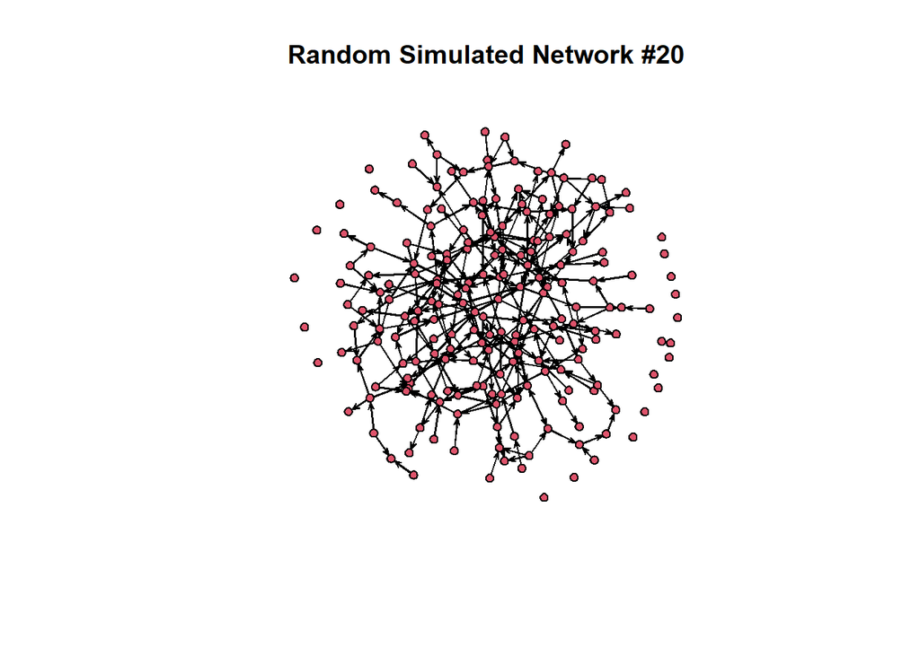

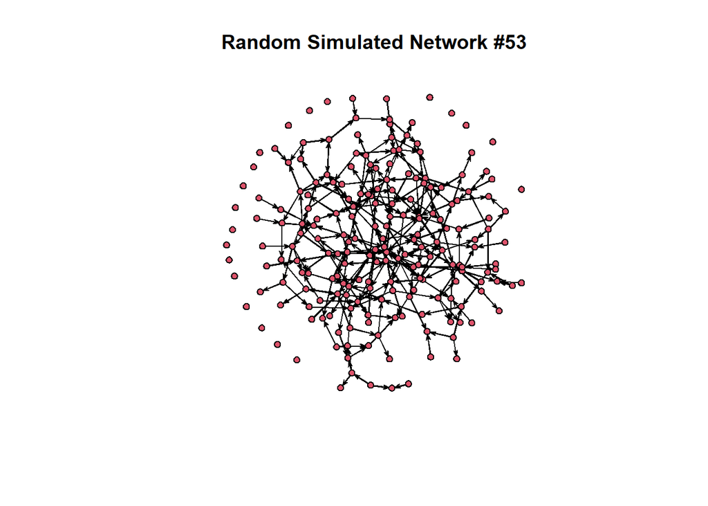

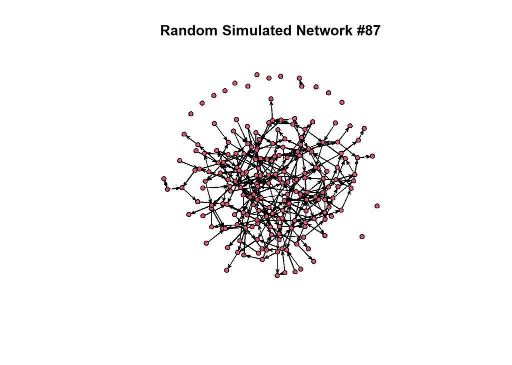

### Histograms of Connections in our 100 Similated Networks

Below we see the number of pairs and triads from our similated networks for our keywords has a higher frequency of zero or one connection. This coincides with our own network outcomes and so we can validate that our keyword network is a common phenomena.

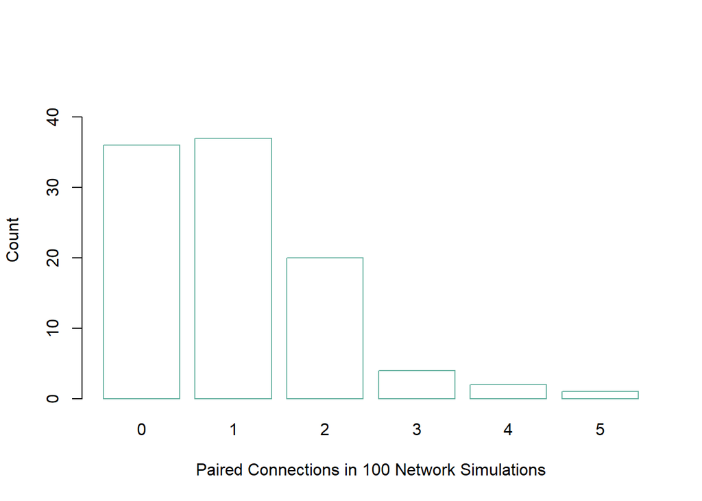

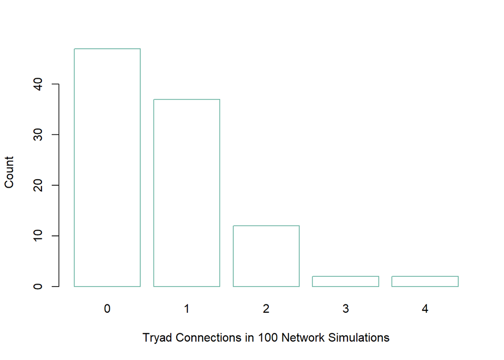

## Authors

### Review Network Connections

```
## edges
##  6621
```

```
## cycle2
##      0
```

```
## cycle3
##      0
```

### Apply ERGM Model

Here our Maximum Likelihood for edges is -8.77 which is essentially our slope, meaning the frequency of researcher connections decrease. We can see this with the MCMC simulations in the next chunck.

```
##
## Call:
## ergm(formula = researcher ~ edges, control = control.ergm(seed = 40))
##
## Maximum Likelihood Coefficients:
##  edges
## -8.779
```

### Simulate networks to validate the ERGM Model

```
##  Network attributes:
##   vertices = 6558
##   directed = TRUE
##   hyper = FALSE
##   loops = FALSE
##   multiple = TRUE
##   bipartite = FALSE
##   total edges= 6604
##     missing edges= 0
##     non-missing edges= 6604
##
##  Vertex attribute names:
##     vertex.names
##
##  Edge attribute names not shown
```

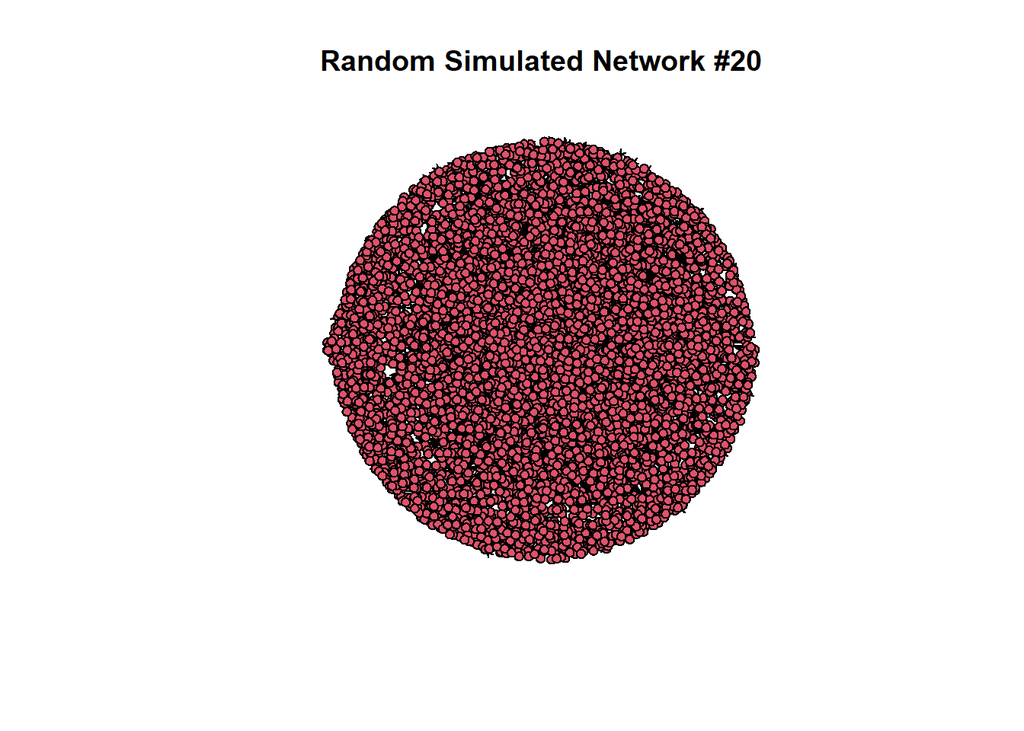

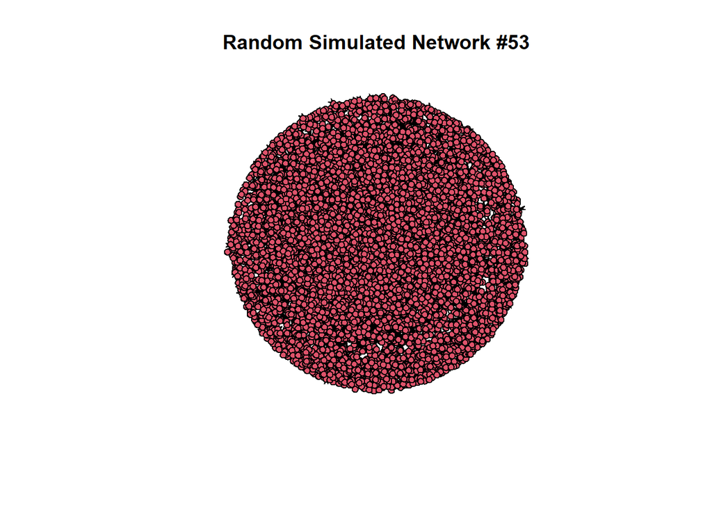

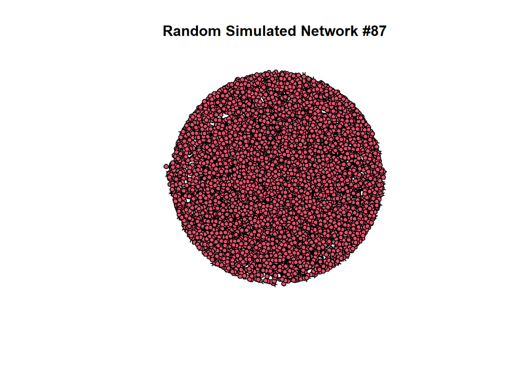

### Histograms of Connections in our 100 Similated Networks

Below we see the number of pairs and triads from our similated networks for our Researchers has a higher frequency of zero or one connection. This coincides with our own network outcomes and so we can validate that our keyword network is a common phenomena.

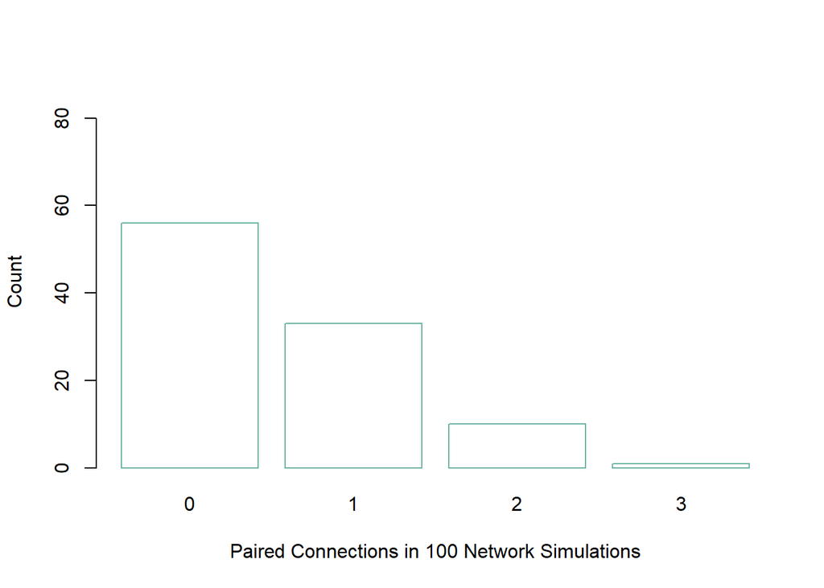

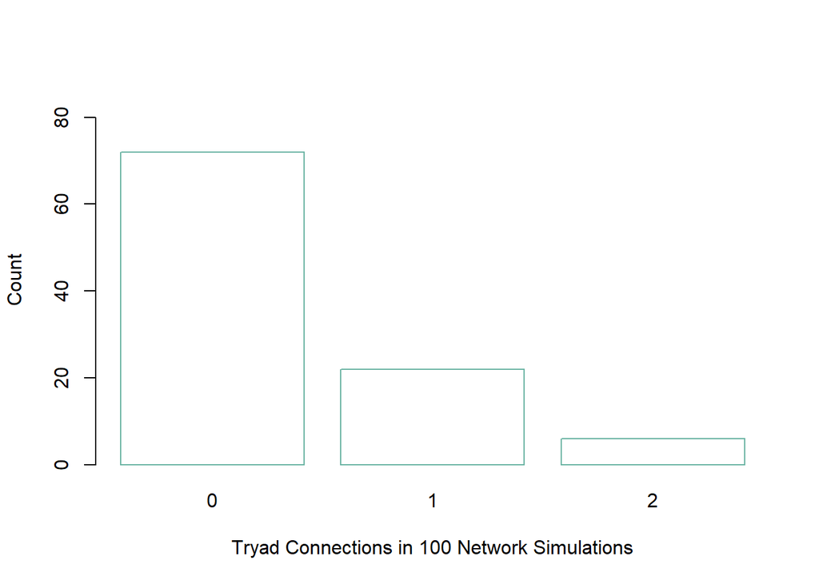